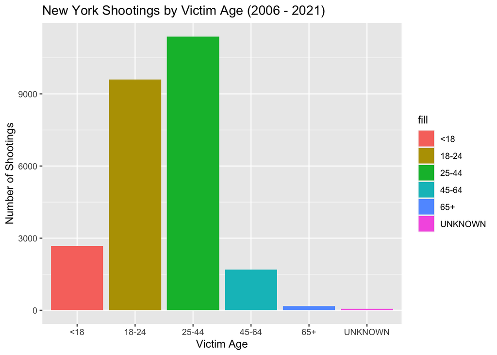

```r
# Plot the number of shootings by victim age
ggplot(df, aes_(x = df$VIC_AGE_GROUP, fill=df$VIC_AGE_GROUP)) + geom_bar(stat = "count") + ggtitle("New York Shootings by Victim Age (2006 - 2021)") + xlab("Victim Age") + ylab("Number of Shootings")
```

[figure not shown]

```r
# Exclude blanks
df = subset(df, df$PERP_AGE_GROUP %in% c("<18", "18-24", "25-44", "45-64", "65+"))
# Generate Plot
ggplot(df, aes_(x = df$PERP_AGE_GROUP, fill=df$PERP_AGE_GROUP)) + geom_bar(stat = "count") + ggtitle("NY Shootings of Young Adults (18-24) by Perpetrator Age (2006 - 2021)") + xlab("Perpetrator Age") + ylab("Number of Shootings")
```

**Data Modeling**

```r
# model the relationship between latitude and longitude of shootings
model = lm(df$Longitude ~ df$Latitude, data = df)
summary(model)
```

```
##
## Call:
## lm(formula = df$Longitude ~ df$Latitude, data = df)
##
## Residuals:
##       Min        1Q    Median        3Q       Max
## -0.287093 -0.032941 -0.006559  0.027357  0.197680
##
## Coefficients:
##               Estimate Std. Error t value Pr(>|t|)
## (Intercept) -80.150596   0.275723 -290.69   <2e-16 ***
## df$Latitude   0.153118   0.006768   22.62   <2e-16 ***
## ---
## Signif. codes:  0 '***' 0.001 '**' 0.01 '*' 0.05 '.' 0.1 ' ' 1
##
## Residual standard error: 0.06918 on 13099 degrees of freedom
## Multiple R-squared:  0.03761,    Adjusted R-squared:  0.03754
## F-statistic: 511.9 on 1 and 13099 DF,  p-value: < 2.2e-16
```

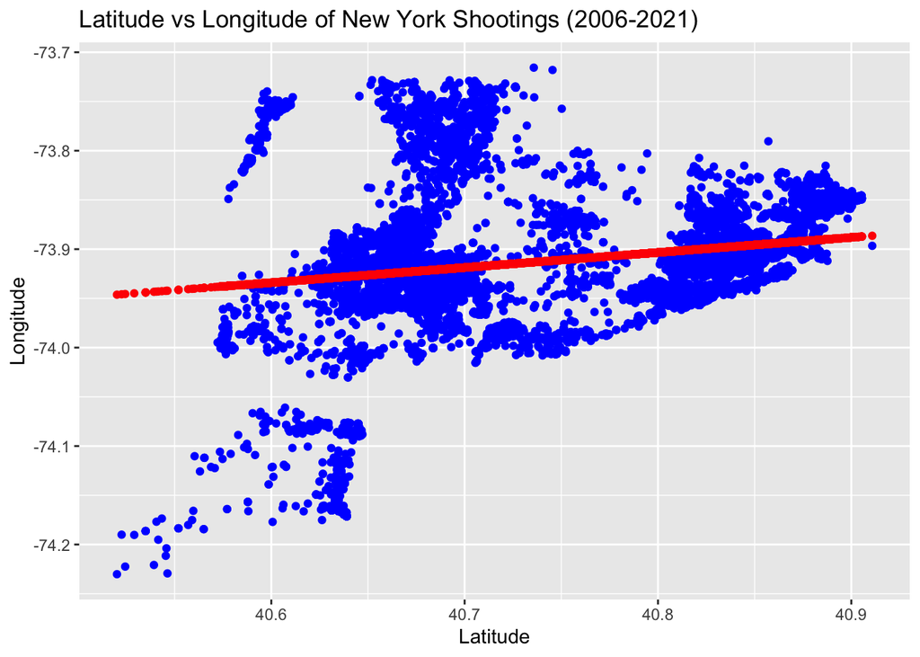

```r
pred = predict(model)
ggplot(df) + geom_point(aes(x = df$Latitude, y = df$Longitude), color="blue") + geom_point(aes(x = df$Latitude, y = pred), color="red") + ggtitle("Latitude vs Longitude of New York Shootings (2006-2021)") + xlab("Latitude") + ylab("Longitude")
```

The linear model indicates that latitude of a shooting in our data set is significantly correlated with its longitude.

**Potential Bias**

The data set could potentially be biased by the exclusion of data from shootings that go unreported. If certain demographics are more likely to be the vicitm or perpetrator of unreported shootings, conclusions drawn from the data may be misleading.